# Reviewers comment v1

Hello Jermaine!

I'm happy to review your project today 🙌

My name is **Gerardo Flores** and you can find me on the HUB as https://hub.tripleten.com/u/dea170e1

You can find my comments under the heading **«Review»**. I will categorize my comments in green, blue or red boxes like this:

**Success:** if everything is done successfully

**Remarks:** if I can give some recommendations or ways to improve the project

**Needs fixing:** if the block requires some corrections. Work cant be accepted with the red comments

Please don't remove my comments :) If you have any questions don't hesitate to respond to my comments in a different section.

**Student comments:** For example like this

**Reviewer's comment v1:**

**Overall Feedback**

Hello Jermaine,

You’ve submitted another project—great work! Your commitment to pushing through the challenges of this program is admirable.

After reviewing your submission, I’ve returned it with some feedback to help you make the necessary improvements.

You can find my more detailed notes within your project notebook in the `Reviewer's comment v1:` section.

**🚧 Suggested Tweaks & Areas for Attention**

- You should calculate the monthly revenue considering to round up the monthly Internet GB consumption to the next whole number.
- Write explicitly your hypothesis.

Keep in mind that revisions are a normal and valuable part of the learning process. Use this feedback to refine your work and resubmit when you’re ready. I know you’re capable of great things, and I’m here to support you every step of the way. Keep going—you’re doing a great job! 🏄

If you find yourself uncertain or in need of further insights, never hesitate to consult with your tutor or ask your questions here. We are here to guide and assist you.

**Reviewer's comment v2:**

**Overall Feedback**

Hello Jermaine,

You’ve submitted another project—great work! Your commitment to pushing through the challenges of this program is admirable.

After reviewing your submission, it is approved.

You can find my more detailed notes within your project notebook in the `Reviewer's comment v2:` section.

If you find yourself uncertain or in need of further insights, never hesitate to consult with your tutor or ask your questions here. We are here to guide and assist you.

# Which one is a better plan?

You work as an analyst for the telecom operator Megaline. The company offers its clients two prepaid plans, Surf and Ultimate. The commercial department wants to know which of the plans brings in more revenue in order to adjust the advertising budget.

You are going to carry out a preliminary analysis of the plans based on a relatively small client selection. You'll have the data on 500 Megaline clients: who the clients are, where they're from, which plan they use, and the number of calls they made and text messages they sent in 2018. Your job is to analyze the clients' behavior and determine which prepaid plan brings in more revenue.

**Reviewer's comment v1**

Great job keeping the additional information about the project goal! Additionally, you could add a short description of the tasks you plan to perform and the available data. This information could be helpful for the notebook reader.

[We've provided you with some commentary to guide your thinking as you complete this project. However, make sure to remove all the bracketed comments before submitting your project.]

[Before you dive into analyzing your data, explain for yourself the purpose of the project and actions you plan to take.]

[Please bear in mind that studying, amending, and analyzing data is an iterative process. It is normal to return to previous steps and correct/expand them to allow for further steps.]

## Prepare the data

[The data for this project is split into several tables. Explore each one to get an initial understanding of the data. Do necessary corrections to each table if necessary.]

## Plans

```
<class 'pandas.core.frame.DataFrame'>
RangeIndex: 2 entries, 0 to 1
Data columns (total 8 columns):
 #   Column                 Non-Null Count  Dtype
---  ------                 --------------  -----
 0   messages_included      2 non-null      int64
 1   mb_per_month_included  2 non-null      int64
 2   minutes_included       2 non-null      int64
 3   usd_monthly_pay        2 non-null      int64
 4   usd_per_gb             2 non-null      int64
 5   usd_per_message        2 non-null      float64
 6   usd_per_minute         2 non-null      float64
 7   plan_name              2 non-null      object
dtypes: float64(2), int64(5), object(1)
memory usage: 256.0+ bytes
```

|  | messages_included | mb_per_month_included | minutes_included | usd_monthly_pay | usd_per_gb | usd_per_message | usd_per_minute | plan_name |
| --- | --- | --- | --- | --- | --- | --- | --- | --- |
| 0 | 50 | 15360 | 500 | 20 | 10 | 0.03 | 0.03 | surf |
| 1 | 1000 | 30720 | 3000 | 70 | 7 | 0.01 | 0.01 | ultimate |

[Describe what you see and notice in the general information and the printed data sample for the above price of data. Are there any issues (inappropriate data types, missing data etc) that may need further investigation and changes? How that can be fixed?]

I observe that there are no issues with the above data sample.

## Fix data

[Fix obvious issues with the data given the initial observations.]

## Enrich data

[Add additional factors to the data if you believe they might be useful.]

## Users

```
<class 'pandas.core.frame.DataFrame'>
RangeIndex: 500 entries, 0 to 499
Data columns (total 8 columns):
 #   Column      Non-Null Count  Dtype
---  ------      --------------  -----
 0   user_id     500 non-null    int64
 1   first_name  500 non-null    object
 2   last_name   500 non-null    object
 3   age         500 non-null    int64
 4   city        500 non-null    object
 5   reg_date    500 non-null    object
 6   plan        500 non-null    object
 7   churn_date  34 non-null     object
dtypes: int64(2), object(6)
memory usage: 31.4+ KB
```

|  | user_id | first_name | last_name | age | city | reg_date | plan | churn_date |
| --- | --- | --- | --- | --- | --- | --- | --- | --- |
| 0 | 1000 | Anamaria | Bauer | 45 | Atlanta-Sandy Springs-Roswell, GA MSA | 2018-12-24 | ultimate | NaN |
| 1 | 1001 | Mickey | Wilkerson | 28 | Seattle-Tacoma-Bellevue, WA MSA | 2018-08-13 | surf | NaN |
| 2 | 1002 | Carlee | Hoffman | 36 | Las Vegas-Henderson-Paradise, NV MSA | 2018-10-21 | surf | NaN |
| 3 | 1003 | Reynaldo | Jenkins | 52 | Tulsa, OK MSA | 2018-01-28 | surf | NaN |
| 4 | 1004 | Leonila | Thompson | 40 | Seattle-Tacoma-Bellevue, WA MSA | 2018-05-23 | surf | NaN |
| ... | ... | ... | ... | ... | ... | ... | ... | ... |
| 495 | 1495 | Fidel | Sharpe | 67 | New York-Newark-Jersey City, NY-NJ-PA MSA | 2018-09-04 | surf | NaN |
| 496 | 1496 | Ariel | Shepherd | 49 | New Orleans-Metairie, LA MSA | 2018-02-20 | surf | NaN |
| 497 | 1497 | Donte | Barrera | 49 | Los Angeles-Long Beach-Anaheim, CA MSA | 2018-12-10 | ultimate | NaN |
| 498 | 1498 | Scot | Williamson | 51 | New York-Newark-Jersey City, NY-NJ-PA MSA | 2018-02-04 | surf | NaN |
| 499 | 1499 | Shena | Dickson | 37 | Orlando-Kissimmee-Sanford, FL MSA | 2018-05-06 | surf | NaN |

500 rows × 8 columns

[Describe what you see and notice in the general information and the printed data sample for the above price of data. Are there any issues (inappropriate data types, missing data etc) that may need further investigation and changes? How that can be fixed?]

I have notice that reg_date & churn_date are objects that need conversion to date_time datatypes.

### Fix Data

[Fix obvious issues with the data given the initial observations.]

|  | user_id | first_name | last_name | age | city | reg_date | plan | churn_date |
| --- | --- | --- | --- | --- | --- | --- | --- | --- |
| 0 | 1000 | Anamaria | Bauer | 45 | Atlanta-Sandy Springs-Roswell, GA MSA | 2018-12-24 | ultimate | NaT |
| 1 | 1001 | Mickey | Wilkerson | 28 | Seattle-Tacoma-Bellevue, WA MSA | 2018-08-13 | surf | NaT |
| 2 | 1002 | Carlee | Hoffman | 36 | Las Vegas-Henderson-Paradise, NV MSA | 2018-10-21 | surf | NaT |
| 3 | 1003 | Reynaldo | Jenkins | 52 | Tulsa, OK MSA | 2018-01-28 | surf | NaT |
| 4 | 1004 | Leonila | Thompson | 40 | Seattle-Tacoma-Bellevue, WA MSA | 2018-05-23 | surf | NaT |

### Enrich Data

[Add additional factors to the data if you believe they might be useful.]

## Calls

```
<class 'pandas.core.frame.DataFrame'>
RangeIndex: 137735 entries, 0 to 137734
Data columns (total 4 columns):
 #   Column     Non-Null Count   Dtype
---  ------     --------------   -----
 0   id         137735 non-null  object
 1   user_id    137735 non-null  int64
 2   call_date  137735 non-null  object
 3   duration   137735 non-null  float64
dtypes: float64(1), int64(1), object(2)
memory usage: 4.2+ MB
```

|  | id | user_id | call_date | duration |
| --- | --- | --- | --- | --- |
| 0 | 1000_93 | 1000 | 2018-12-27 | 8.52 |
| 1 | 1000_145 | 1000 | 2018-12-27 | 13.66 |
| 2 | 1000_247 | 1000 | 2018-12-27 | 14.48 |
| 3 | 1000_309 | 1000 | 2018-12-28 | 5.76 |
| 4 | 1000_380 | 1000 | 2018-12-30 | 4.22 |
| ... | ... | ... | ... | ... |
| 137730 | 1499_199 | 1499 | 2018-11-21 | 8.72 |
| 137731 | 1499_200 | 1499 | 2018-10-20 | 10.89 |
| 137732 | 1499_201 | 1499 | 2018-09-21 | 8.12 |
| 137733 | 1499_202 | 1499 | 2018-10-10 | 0.37 |
| 137734 | 1499_203 | 1499 | 2018-12-29 | 13.86 |

137735 rows × 4 columns

[Describe what you see and notice in the general information and the printed data sample for the above price of data. Are there any issues (inappropriate data types, missing data etc) that may need further investigation and changes? How that can be fixed?]

I have noticed that call_date are objects that need conversion to date_time datatypes. I have noticed that duration needs to be rounded up with ceil function.

### Fix data

[Fix obvious issues with the data given the initial observations.]

### Enrich data

[Add additional factors to the data if you believe they might be useful.]

|  | id | user_id | call_date | duration |
| --- | --- | --- | --- | --- |
| 0 | 1000_93 | 1000 | 2018-12-27 | 9 |
| 1 | 1000_145 | 1000 | 2018-12-27 | 14 |
| 2 | 1000_247 | 1000 | 2018-12-27 | 15 |
| 3 | 1000_309 | 1000 | 2018-12-28 | 6 |
| 4 | 1000_380 | 1000 | 2018-12-30 | 5 |

## Messages

```
<class 'pandas.core.frame.DataFrame'>
RangeIndex: 76051 entries, 0 to 76050
Data columns (total 3 columns):
 #   Column        Non-Null Count  Dtype
---  ------        --------------  -----
 0   id            76051 non-null  object
 1   user_id       76051 non-null  int64
 2   message_date  76051 non-null  object
dtypes: int64(1), object(2)
memory usage: 1.7+ MB
```

|  | id | user_id | message_date |
| --- | --- | --- | --- |
| 0 | 1000_125 | 1000 | 2018-12-27 |
| 1 | 1000_160 | 1000 | 2018-12-31 |
| 2 | 1000_223 | 1000 | 2018-12-31 |
| 3 | 1000_251 | 1000 | 2018-12-27 |
| 4 | 1000_255 | 1000 | 2018-12-26 |
| ... | ... | ... | ... |
| 76046 | 1497_526 | 1497 | 2018-12-24 |
| 76047 | 1497_536 | 1497 | 2018-12-24 |
| 76048 | 1497_547 | 1497 | 2018-12-31 |
| 76049 | 1497_558 | 1497 | 2018-12-24 |
| 76050 | 1497_613 | 1497 | 2018-12-23 |

76051 rows × 3 columns

[Describe what you see and notice in the general information and the printed data sample for the above price of data. Are there any issues (inappropriate data types, missing data etc) that may need further investigation and changes? How that can be fixed?]

I have noticed that message_date column needs to be converted to date_time datatype.

### Fix data

[Fix obvious issues with the data given the initial observations.]

### Enrich data

[Add additional factors to the data if you believe they might be useful.]

## Internet

```
<class 'pandas.core.frame.DataFrame'>
RangeIndex: 104825 entries, 0 to 104824
Data columns (total 4 columns):
 #   Column        Non-Null Count   Dtype
---  ------        --------------   -----
 0   id            104825 non-null  object
 1   user_id       104825 non-null  int64
 2   session_date  104825 non-null  object
 3   mb_used       104825 non-null  float64
dtypes: float64(1), int64(1), object(2)
memory usage: 3.2+ MB
```

|  | id | user_id | session_date | mb_used |
| --- | --- | --- | --- | --- |
| 0 | 1000_13 | 1000 | 2018-12-29 | 89.86 |
| 1 | 1000_204 | 1000 | 2018-12-31 | 0.00 |
| 2 | 1000_379 | 1000 | 2018-12-28 | 660.40 |
| 3 | 1000_413 | 1000 | 2018-12-26 | 270.99 |
| 4 | 1000_442 | 1000 | 2018-12-27 | 880.22 |
| ... | ... | ... | ... | ... |
| 104820 | 1499_215 | 1499 | 2018-10-20 | 218.06 |
| 104821 | 1499_216 | 1499 | 2018-12-30 | 304.72 |
| 104822 | 1499_217 | 1499 | 2018-09-22 | 292.75 |
| 104823 | 1499_218 | 1499 | 2018-12-07 | 0.00 |
| 104824 | 1499_219 | 1499 | 2018-12-24 | 758.31 |

104825 rows × 4 columns

[Describe what you see and notice in the general information and the printed data sample for the above price of data. Are there any issues (inappropriate data types, missing data etc) that may need further investigation and changes? How that can be fixed?]

i noticed that the session_date column needs conversion to datetime datatype.

### Fix data

[Fix obvious issues with the data given the initial observations.]

### Enrich data

[Add additional factors to the data if you believe they might be useful.]

**Reviewer's comment v1**

Great data overview and comments at each dataset.

## Study plan conditions

[It is critical to understand how the plans work, how users are charged based on their plan subscription. So, we suggest printing out the plan information to view their conditions once again.]

|  | messages_included | mb_per_month_included | minutes_included | usd_monthly_pay | usd_per_gb | usd_per_message | usd_per_minute | plan_name |
| --- | --- | --- | --- | --- | --- | --- | --- | --- |
| 0 | 50 | 15360 | 500 | 20 | 10 | 0.03 | 0.03 | surf |
| 1 | 1000 | 30720 | 3000 | 70 | 7 | 0.01 | 0.01 | ultimate |

## Aggregate data per user

[Now, as the data is clean, aggregate data per user per period in order to have just one record per user per period. It should ease the further analysis a lot.]

|  | user_id | month | calls_sum |
| --- | --- | --- | --- |
| 0 | 1000 | 12 | 124 |
| 1 | 1001 | 8 | 182 |
| 2 | 1001 | 9 | 315 |
| 3 | 1001 | 10 | 393 |
| 4 | 1001 | 11 | 426 |
| ... | ... | ... | ... |
| 2253 | 1498 | 12 | 339 |
| 2254 | 1499 | 9 | 346 |
| 2255 | 1499 | 10 | 385 |
| 2256 | 1499 | 11 | 308 |
| 2257 | 1499 | 12 | 496 |

2258 rows × 3 columns

|  | user_id | month | messages_count |
| --- | --- | --- | --- |
| 0 | 1000 | 12 | 11 |
| 1 | 1001 | 8 | 30 |
| 2 | 1001 | 9 | 44 |
| 3 | 1001 | 10 | 53 |
| 4 | 1001 | 11 | 36 |
| ... | ... | ... | ... |
| 1801 | 1496 | 9 | 21 |
| 1802 | 1496 | 10 | 18 |
| 1803 | 1496 | 11 | 13 |
| 1804 | 1496 | 12 | 11 |
| 1805 | 1497 | 12 | 50 |

1806 rows × 3 columns

|  | user_id | month | internet_sum |
| --- | --- | --- | --- |
| 0 | 1000 | 12 | 1901.47 |
| 1 | 1001 | 8 | 6919.15 |
| 2 | 1001 | 9 | 13314.82 |
| 3 | 1001 | 10 | 22330.49 |
| 4 | 1001 | 11 | 18504.30 |
| ... | ... | ... | ... |
| 2272 | 1498 | 12 | 23137.69 |
| 2273 | 1499 | 9 | 12984.76 |
| 2274 | 1499 | 10 | 19492.43 |
| 2275 | 1499 | 11 | 16813.83 |
| 2276 | 1499 | 12 | 22059.21 |

2277 rows × 3 columns

|  | user_id | month | internet_count |
| --- | --- | --- | --- |
| 0 | 1000 | 12 | 5 |
| 1 | 1001 | 8 | 25 |
| 2 | 1001 | 9 | 53 |
| 3 | 1001 | 10 | 56 |
| 4 | 1001 | 11 | 51 |
| ... | ... | ... | ... |
| 2272 | 1498 | 12 | 65 |
| 2273 | 1499 | 9 | 45 |
| 2274 | 1499 | 10 | 61 |
| 2275 | 1499 | 11 | 49 |
| 2276 | 1499 | 12 | 65 |

2277 rows × 3 columns

[Put the aggregate data together into one DataFrame so that one record in it would represent what an unique user consumed in a given month.]

|  | user_id | month | calls_sum | messages_count | internet_sum | internet_count |
| --- | --- | --- | --- | --- | --- | --- |
| 0 | 1000 | 12 | 124.0 | 11.0 | 1901.47 | 5.0 |
| 1 | 1001 | 8 | 182.0 | 30.0 | 6919.15 | 25.0 |
| 2 | 1001 | 9 | 315.0 | 44.0 | 13314.82 | 53.0 |
| 3 | 1001 | 10 | 393.0 | 53.0 | 22330.49 | 56.0 |
| 4 | 1001 | 11 | 426.0 | 36.0 | 18504.30 | 51.0 |
| ... | ... | ... | ... | ... | ... | ... |
| 2288 | 1349 | 12 | NaN | 61.0 | 13039.91 | 27.0 |
| 2289 | 1361 | 5 | NaN | 2.0 | 1519.69 | 9.0 |
| 2290 | 1482 | 10 | NaN | 2.0 | NaN | NaN |
| 2291 | 1108 | 12 | NaN | NaN | 233.17 | 2.0 |
| 2292 | 1311 | 6 | NaN | NaN | 1498.83 | 9.0 |

2293 rows × 6 columns

|  | user_id | month | calls_sum | messages_count | internet_sum | internet_count | first_name | last_name | age | city | ... | plan | churn_date | messages_included | mb_per_month_included | minutes_included | usd_monthly_pay | usd_per_gb | usd_per_message | usd_per_minute | plan_name |
| --- | --- | --- | --- | --- | --- | --- | --- | --- | --- | --- | --- | --- | --- | --- | --- | --- | --- | --- | --- | --- | --- |
| 0 | 1000 | 12 | 124.0 | 11.0 | 1901.47 | 5.0 | Anamaria | Bauer | 45 | Atlanta-Sandy Springs-Roswell, GA MSA | ... | ultimate | NaT | 1000 | 30720 | 3000 | 70 | 7 | 0.01 | 0.01 | ultimate |
| 1 | 1001 | 8 | 182.0 | 30.0 | 6919.15 | 25.0 | Mickey | Wilkerson | 28 | Seattle-Tacoma-Bellevue, WA MSA | ... | surf | NaT | 50 | 15360 | 500 | 20 | 10 | 0.03 | 0.03 | surf |
| 2 | 1001 | 9 | 315.0 | 44.0 | 13314.82 | 53.0 | Mickey | Wilkerson | 28 | Seattle-Tacoma-Bellevue, WA MSA | ... | surf | NaT | 50 | 15360 | 500 | 20 | 10 | 0.03 | 0.03 | surf |
| 3 | 1001 | 10 | 393.0 | 53.0 | 22330.49 | 56.0 | Mickey | Wilkerson | 28 | Seattle-Tacoma-Bellevue, WA MSA | ... | surf | NaT | 50 | 15360 | 500 | 20 | 10 | 0.03 | 0.03 | surf |
| 4 | 1001 | 11 | 426.0 | 36.0 | 18504.30 | 51.0 | Mickey | Wilkerson | 28 | Seattle-Tacoma-Bellevue, WA MSA | ... | surf | NaT | 50 | 15360 | 500 | 20 | 10 | 0.03 | 0.03 | surf |
| ... | ... | ... | ... | ... | ... | ... | ... | ... | ... | ... | ... | ... | ... | ... | ... | ... | ... | ... | ... | ... | ... |
| 2288 | 1349 | 12 | 0.0 | 61.0 | 13039.91 | 27.0 | Florentina | Diaz | 69 | Boston-Cambridge-Newton, MA-NH MSA | ... | surf | NaT | 50 | 15360 | 500 | 20 | 10 | 0.03 | 0.03 | surf |
| 2289 | 1361 | 5 | 0.0 | 2.0 | 1519.69 | 9.0 | Jacelyn | Hoffman | 45 | Birmingham-Hoover, AL MSA | ... | surf | NaT | 50 | 15360 | 500 | 20 | 10 | 0.03 | 0.03 | surf |
| 2290 | 1482 | 10 | 0.0 | 2.0 | 0.00 | 0.0 | Armand | Glenn | 70 | New York-Newark-Jersey City, NY-NJ-PA MSA | ... | ultimate | NaT | 1000 | 30720 | 3000 | 70 | 7 | 0.01 | 0.01 | ultimate |
| 2291 | 1108 | 12 | 0.0 | 0.0 | 233.17 | 2.0 | Porfirio | Kane | 45 | Salt Lake City, UT MSA | ... | ultimate | NaT | 1000 | 30720 | 3000 | 70 | 7 | 0.01 | 0.01 | ultimate |
| 2292 | 1311 | 6 | 0.0 | 0.0 | 1498.83 | 9.0 | Cherlyn | Saunders | 69 | Memphis, TN-MS-AR MSA | ... | ultimate | NaT | 1000 | 30720 | 3000 | 70 | 7 | 0.01 | 0.01 | ultimate |

2293 rows × 21 columns

**Reviewer's comment v1:**

The revenue is well calculated; however, in order to maximize the revenue from each user without increasing their plan, you should round up the monthly Internet GB consumption to the next whole number (previously you did something similar for calls).

[Calculate the monthly revenue from each user (subtract the free package limit from the total number of calls, text messages, and data; multiply the result by the calling plan value; add the monthly charge depending on the calling plan). N.B. This might not be as trivial as just a couple of lines given the plan conditions! So, it's okay to spend some time on it.]

|  | user_id | month | plan | calls_sum | messages_count | internet_sum | call_overage | message_overage | internet_overage | monthly_revenue |
| --- | --- | --- | --- | --- | --- | --- | --- | --- | --- | --- |
| 0 | 1000 | 12 | ultimate | 124.0 | 11.0 | 1901.47 | 0.00 | 0.00 | 0.000000 | 70.000000 |
| 1 | 1001 | 8 | surf | 182.0 | 30.0 | 6919.15 | 0.00 | 0.00 | 0.000000 | 20.000000 |
| 2 | 1001 | 9 | surf | 315.0 | 44.0 | 13314.82 | 0.00 | 0.00 | 0.000000 | 20.000000 |
| 3 | 1001 | 10 | surf | 393.0 | 53.0 | 22330.49 | 0.00 | 0.09 | 68.071191 | 88.161191 |
| 4 | 1001 | 11 | surf | 426.0 | 36.0 | 18504.30 | 0.00 | 0.00 | 30.706055 | 50.706055 |
| 5 | 1001 | 12 | surf | 412.0 | 44.0 | 19369.18 | 0.00 | 0.00 | 39.152148 | 59.152148 |
| 6 | 1002 | 10 | surf | 59.0 | 15.0 | 6552.01 | 0.00 | 0.00 | 0.000000 | 20.000000 |
| 7 | 1002 | 11 | surf | 386.0 | 32.0 | 19345.08 | 0.00 | 0.00 | 38.916797 | 58.916797 |
| 8 | 1002 | 12 | surf | 384.0 | 41.0 | 14396.24 | 0.00 | 0.00 | 0.000000 | 20.000000 |
| 9 | 1003 | 12 | surf | 1104.0 | 50.0 | 27044.14 | 18.12 | 0.00 | 114.102930 | 152.222930 |

**Reviewer's comment v1**

Well done!

## Study user behaviour

[Calculate some useful descriptive statistics for the aggregated and merged data, which typically reveal an overall picture captured by the data. Draw useful plots to help the understanding. Given that the main task is to compare the plans and decide on which one is more profitable, the statistics and the plots should be calculated on a per-plan basis.]

[There are relevant hints in the comments for Calls but they are not provided for Messages and Internet though the principle of statistical study is the same for them as for Calls.]

### Calls

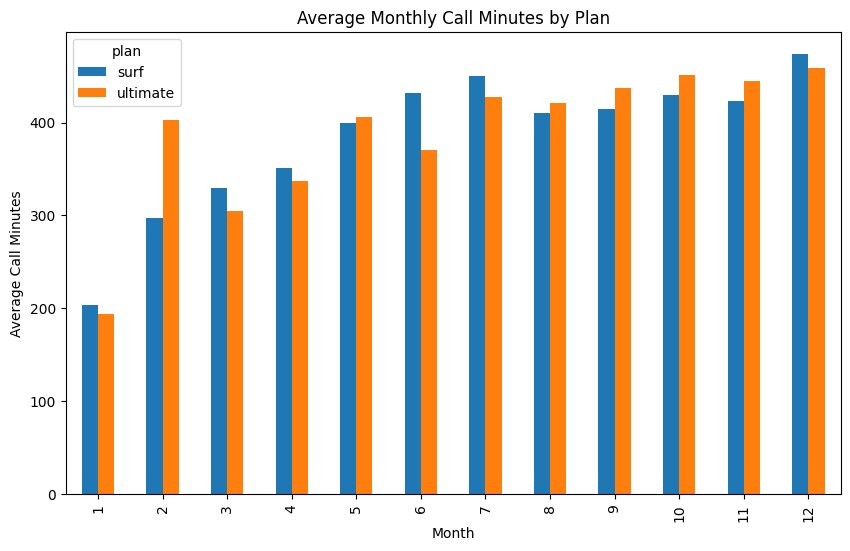

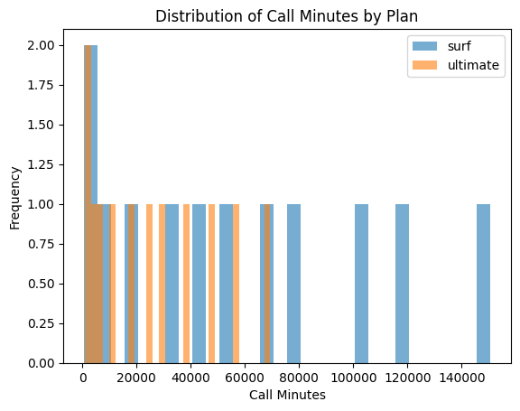

[Calculate the mean and the variable of the call duration to reason on whether users on the different plans have different behaviours for their calls.]

```
429.2834714348016
```

```
55847.17877118995
```

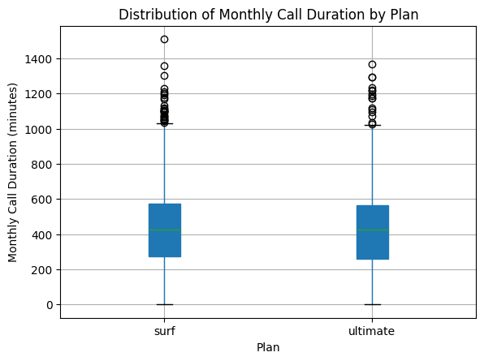

[Formulate conclusions on how the users behave in terms of calling. Is their behaviour different between the plans?]

there are no major behavior differences between users in terms of calls. The only main behavior difference i notice is with in the frequency of calls. As the call minutes increase up toward 80000 the frequency in ultimate plan users stops. This tells me that ultimate users aren't pushing up against there usage limits.

### Messages

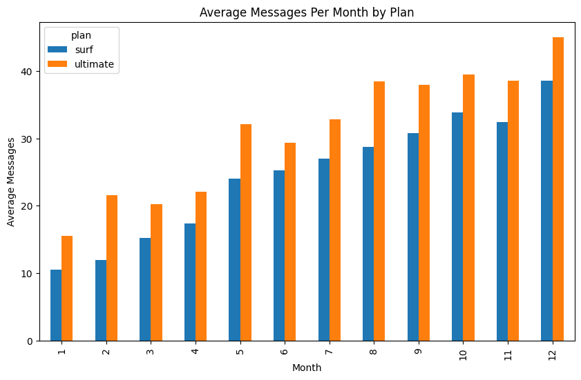

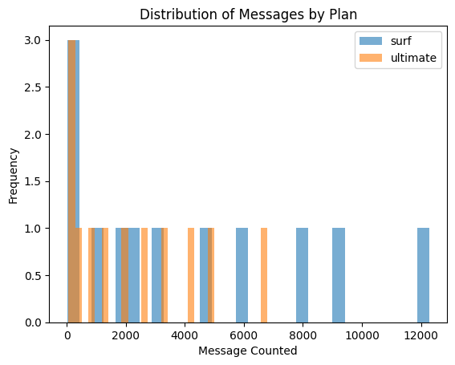

```
33.166593981683384
```

```
1160.770663655758
```

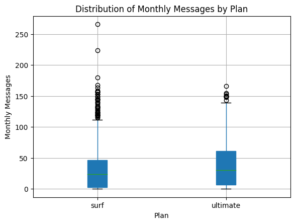

```
Message usage statistics by plan:
               mean        std  median  min    max
plan
surf      31.159568  33.566717    24.0  0.0  266.0
ultimate  37.551389  34.767179    30.0  0.0  166.0
```

[Formulate conclusions on how the users behave in terms of messaging. Is their behaviour different between the plans?]

I've noticed that users on Ultimate Plan use slightly more messages per month than users on Surf Plan.

### Internet

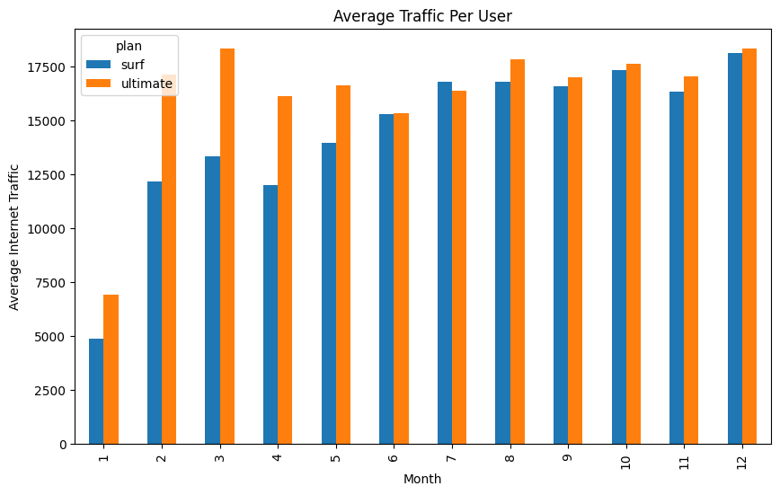

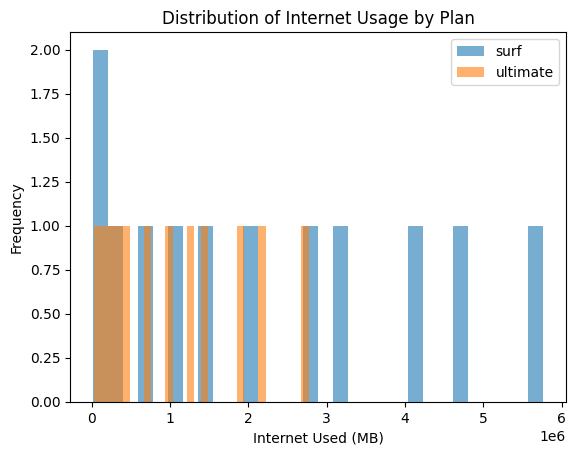

```
16764.39760575665
```

```
63476873.81347372
```

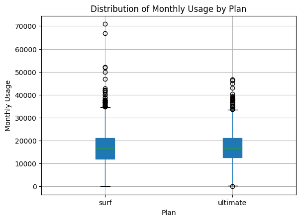

[Formulate conclusions on how the users tend to consume the internet traffic? Is their behaviour different between the plans?]

I've noticed that ultimate plan users have more internet traffic than surf plan users.

## Revenue

[Likewise you have studied the user behaviour, statistically describe the revenue between the plans.]

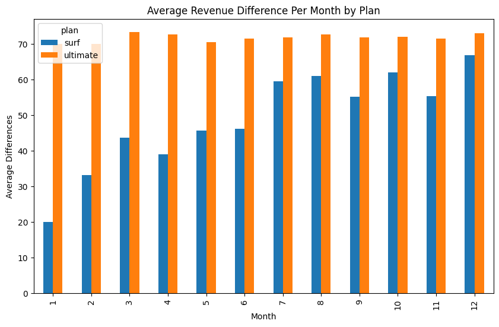

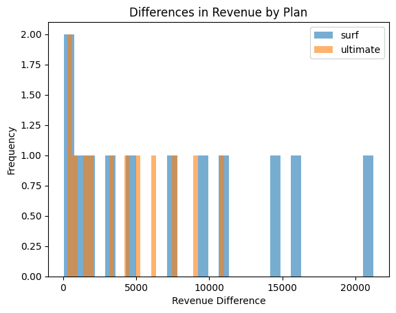

```
62.208008757972635
```

```
2070.984354577875
```

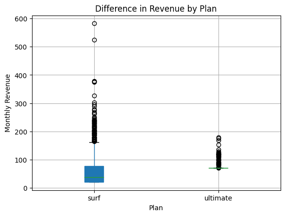

[Formulate conclusions about how the revenue differs between the plans.]

Statistically, I've noticed the Ultimate Plan produces significantly more revenue per user then the Surf Plan each month.

**Reviewer's comment v1**

Great analysis!, also each section has correct cunclusions

## Test statistical hypotheses

[Test the hypothesis that the average revenue from users of the Ultimate and Surf calling plans differs.]

[Formulate the null and the alternative hypotheses, choose the statistical test, decide on the alpha value.]

Null Hypotheses There is no difference in the average monthly revenue between Ultimate and Surf plan users.

Alternative Hypotheses There is a difference in the average monthly revenue between Ultimate and Surf plan users.

```
p-value: 8.530525302626667e-24
We reject the null hypothesis
```

There is a statistically significant difference in average monthly revenue between Ultimate and Surf plan users.

**Reviewer's comment v1:**

Good attempt; however you must explicitly write your null hypothesis and the alternative.

**Reviewer's comment v2**

Done.

[Test the hypothesis that the average revenue from users in the NY-NJ area is different from that of the users from the other regions.]

[Formulate the null and the alternative hypotheses, choose the statistical test, decide on the alpha value.]

Null Hypotheses There is no difference in the average monthly revenue between users in the NY–NJ region and users in other regions.

Alternative Hypotheses The average monthly revenue of users in the NY–NJ region differs from that of users in other regions.

```
p-value: 0.020128295172528086
We reject the null hypothesis
```

The average monthly revenue of users in the NY–NJ region differs from that of users in other regions.

**Reviewer's comment v1:**

Good attempt; however you must explicitly write your null hypothesis and the alternative.

**Reviewer's comment v2**

Done.

## General conclusion

[List your important conclusions in this final section, make sure they cover all those important decisions (assumptions) that you've made and that led you to the way you processed and analyzed the data.]

Data Preparation

Several columns were initially stored as object datatypes, so I converted them into appropriate datetime formats to ensure accurate time-based analysis.

I applied the ceil() function to round up call durations to the nearest minute, ensuring consistent and realistic billing and usage calculations.

Behavioral Insights

There were no major behavioral differences between users of the two calling plans in terms of average call durations.

The main behavioral difference appeared in call frequency: as total call minutes increased (approaching ~80,000), the frequency of calls among Ultimate plan users plateaued — suggesting that they are not constrained by usage limits, unlike Surf plan users.

Ultimate plan users sent slightly more messages per month compared to Surf plan users.

Ultimate plan users also demonstrated higher internet traffic, indicating heavier data consumption.

Revenue Insights

Statistical testing showed that the Ultimate Plan produces significantly more revenue per user than the Surf Plan each month.

When testing the hypothesis that average revenue differs between users in the NY–NJ area and other regions, the p-value = 0.0201, which is less than α = 0.05 → Reject the null hypothesis.

Conclusion: There is a statistically significant difference in average revenue between NY–NJ users and users in other regions.

When testing the hypothesis that average revenue differs between Ultimate and Surf plan users, the p-value = 8.53×10⁻²⁴, also less than α = 0.05 → Reject the null hypothesis.

Overall Summary

After cleaning, transforming, and analyzing the dataset:

Data quality and type conversions were crucial for accurate analysis.

Behaviorally, Ultimate users tend to use more data and messages but have similar calling patterns.

Statistically, both regional location (NY–NJ vs. others) and plan type (Ultimate vs. Surf) have significant effects on average revenue.

**Reviewer's comment v1**

Great conclusions!